# NIH Aging Data Exploration

Ben A. Flanagan

### Notes:

There are a few issues with these data. How are we going to deal with the sampling at the various time points? I could imagine subtracting the number sampled from the total at day 28 and all subsequent counts to develop proportions. That may be the most conservative approach, but I am still unsure. I am still fishing for ideas as how to deal with the sampling artifact.

In the following analyses, I used ALL data; not just crosses deemed ‘usable’.

```
##
## FF FS SF SS
## 35 26 16 25
```

```
##
##              FF FS SF SS
##   not_usable 26 15  7 16
##   usable      9 11  9  9
```

## Sex ratio

For the following plots I removed any specific sex within a clutch at a given day where we had no data.

Below are sex specific counts and sex ratio wrapped over days.

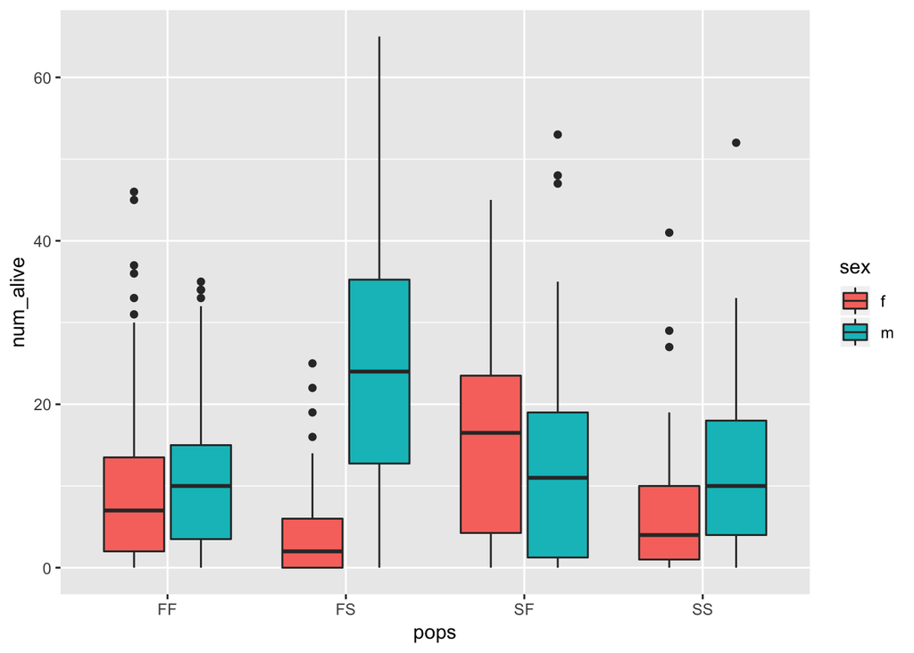

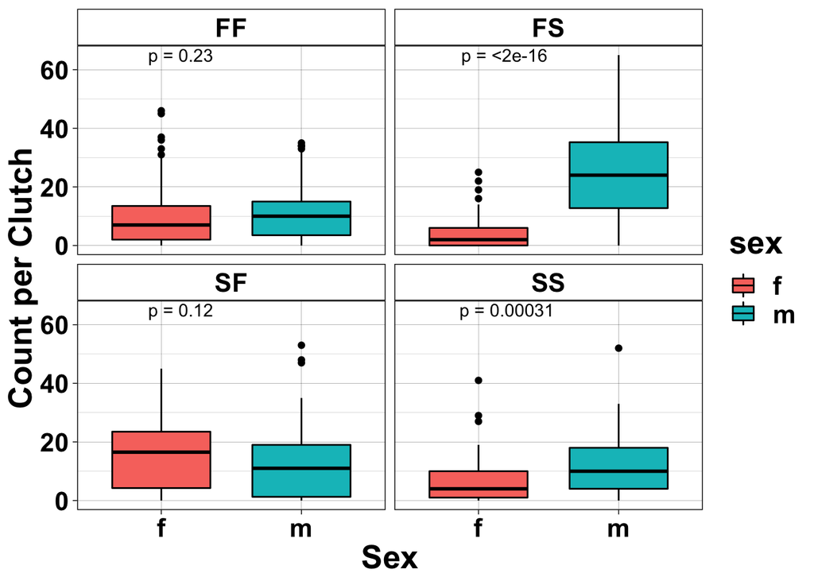

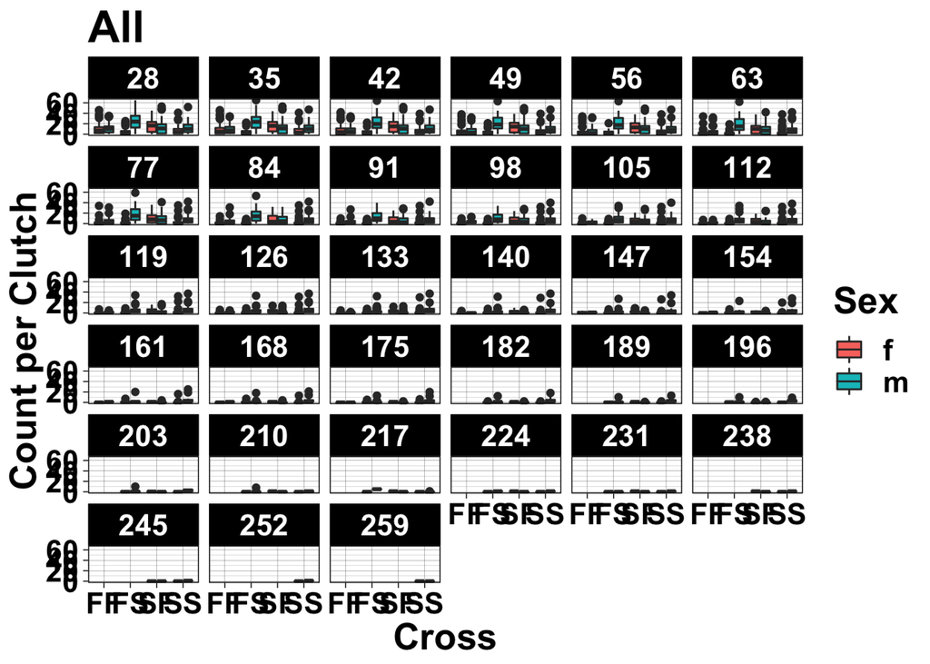

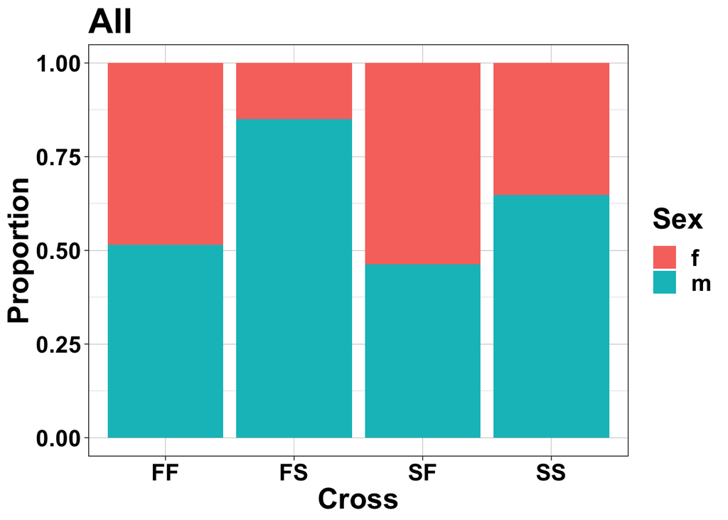

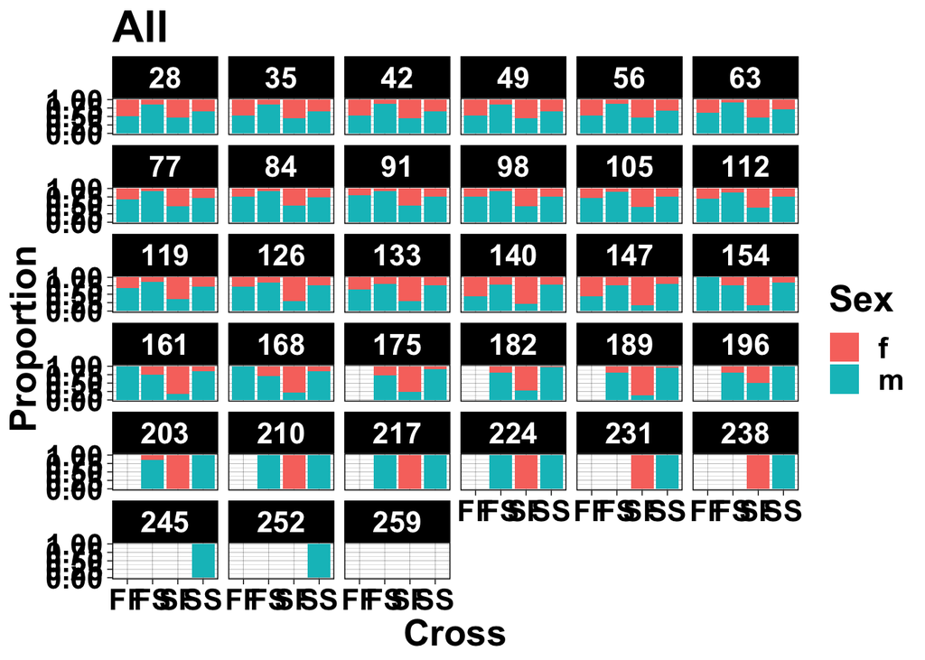

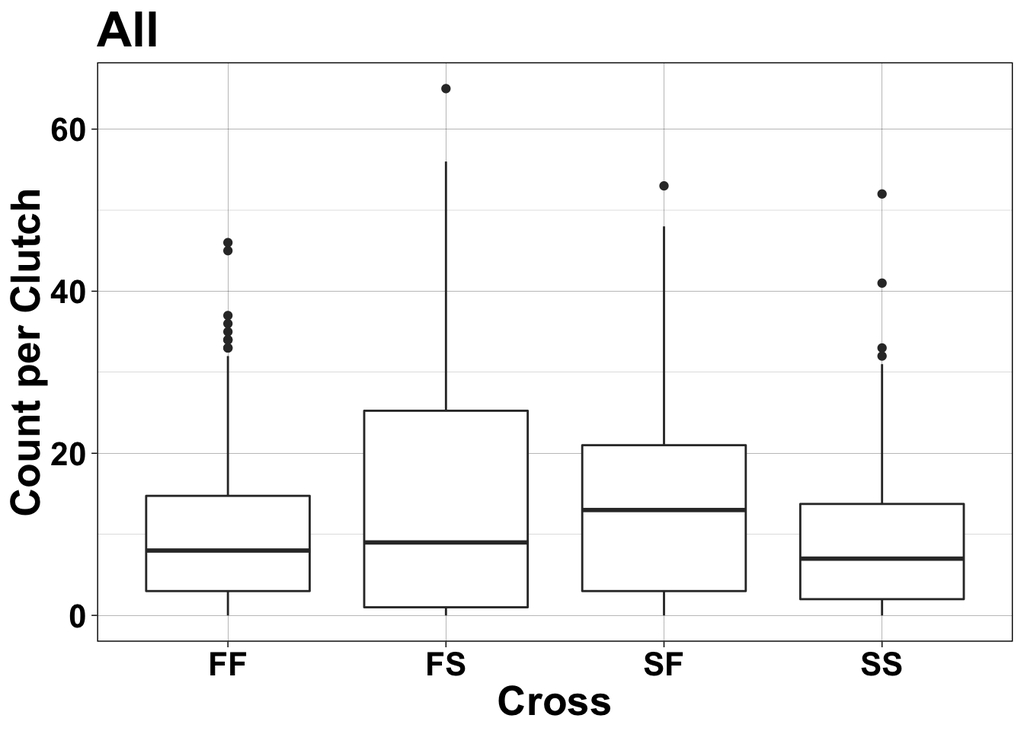

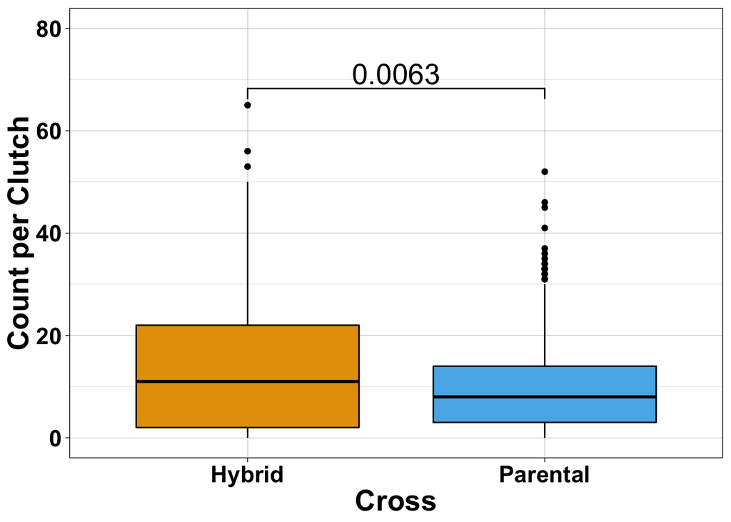

```
##
##  Welch Two Sample t-test
##
## data:  subset(tmp, parental == "Parental")$num_alive and subset(tmp, parental == "Hybrid")$num_alive
## t = -4.1844, df = 387.84, p-value = 3.539e-05
## alternative hypothesis: true difference in means is not equal to 0
## 95 percent confidence interval:
##  -6.601462 -2.380961
## sample estimates:
## mean of x mean of y
##  9.953704 14.444915
```

## Survival plots

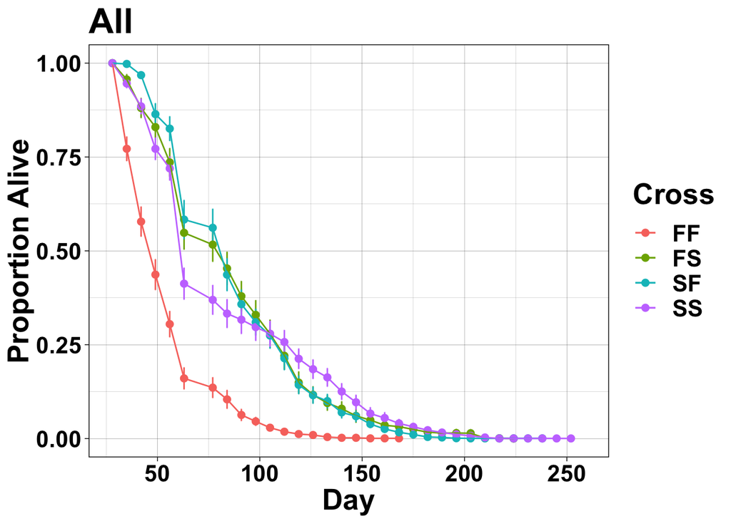

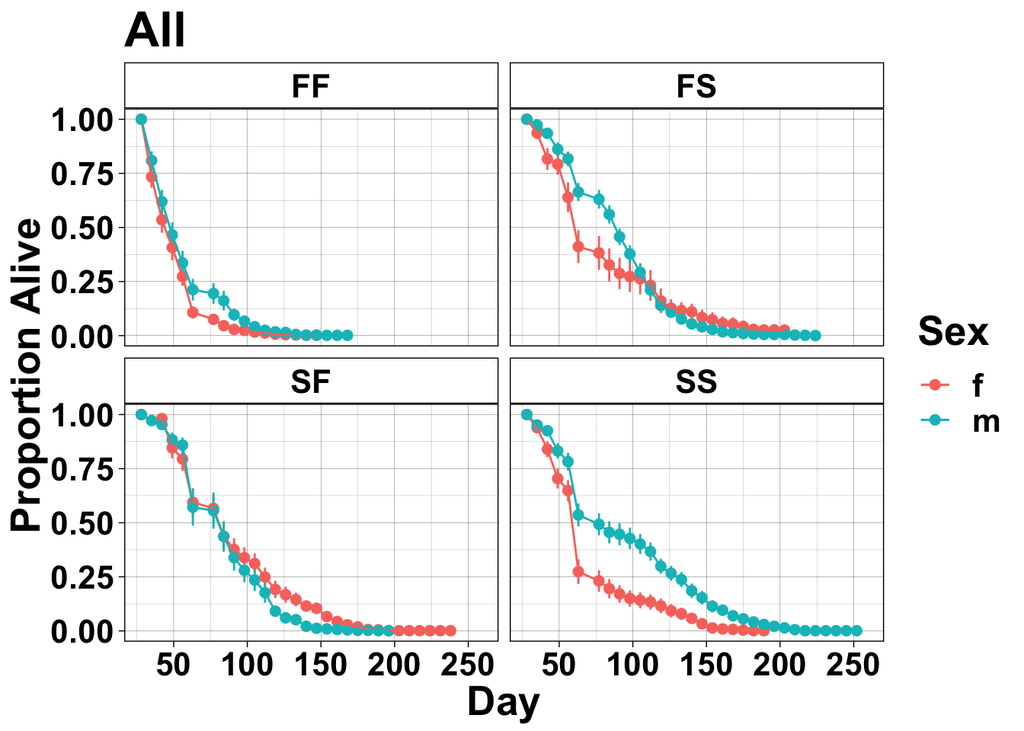

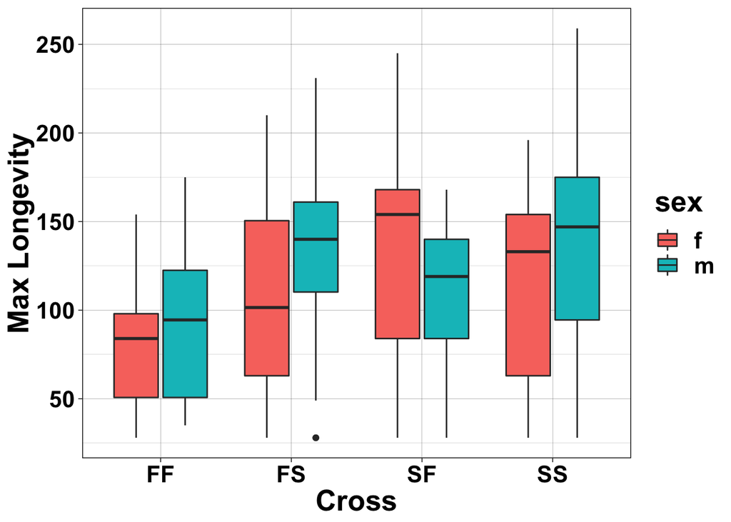

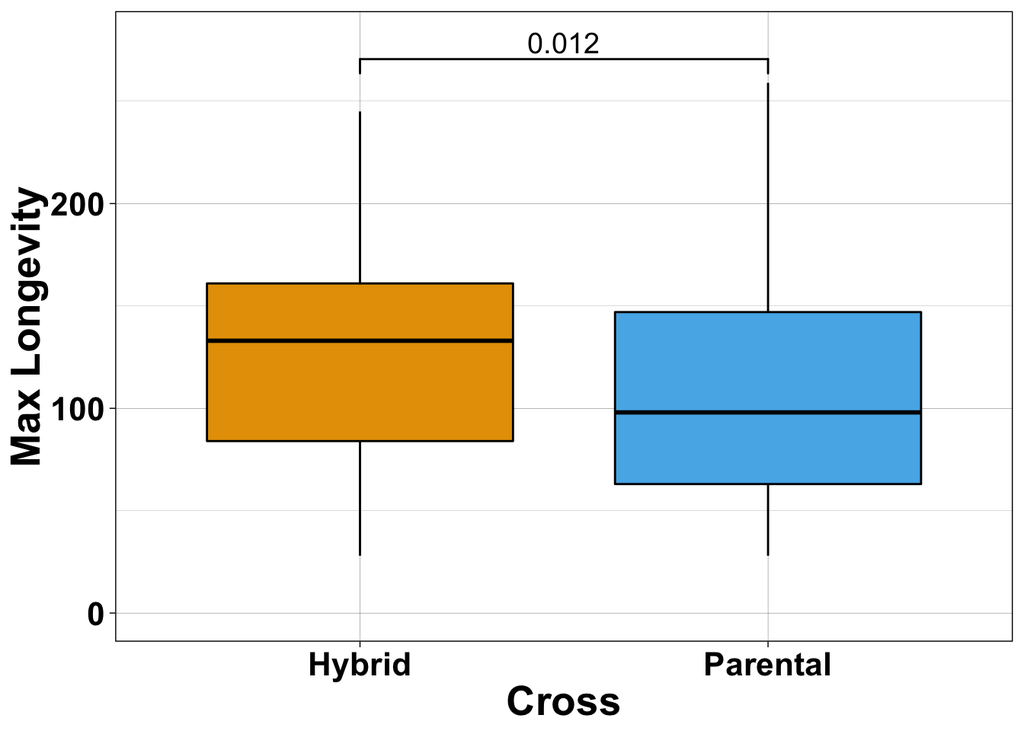

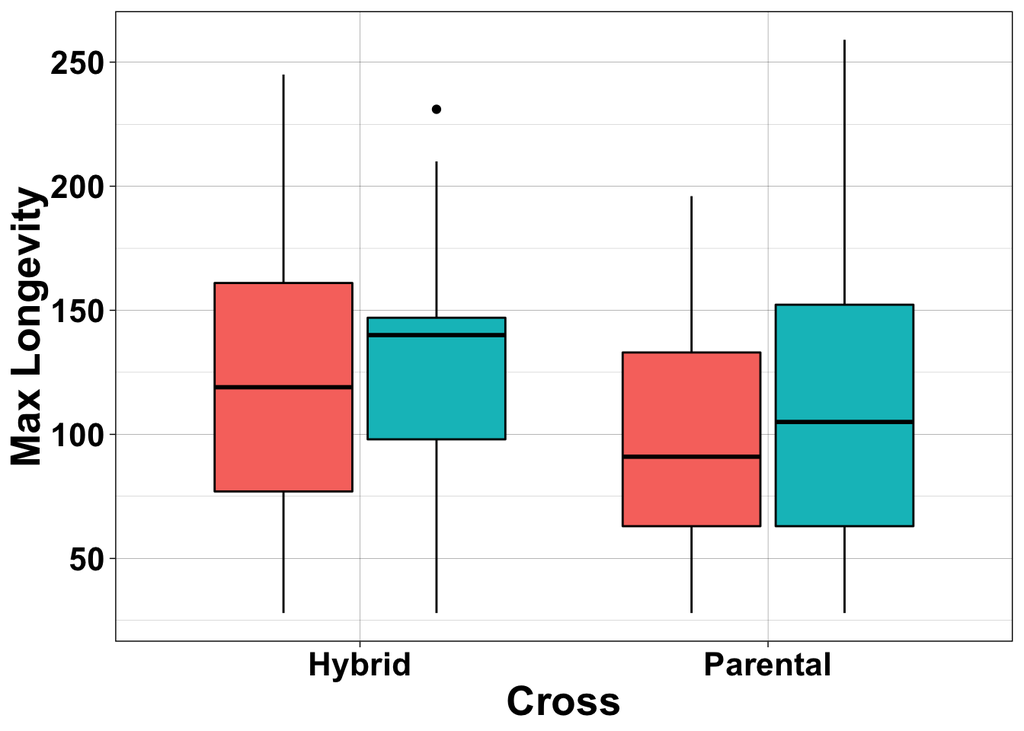

```
##              Df Sum Sq Mean Sq F value   Pr(>F)
## sex           1   9234    9234   3.954   0.0481 *
## pops          3  55935   18645   7.984 4.62e-05 ***
## sex:pops      3  18432    6144   2.631   0.0511 .
## Residuals   207 483412    2335
## ---
## Signif. codes:  0 '***' 0.001 '**' 0.01 '*' 0.05 '.' 0.1 ' ' 1
```

```
##   Tukey multiple comparisons of means
##     95% family-wise confidence level
##
## Fit: aov(formula = max_longevity ~ sex * pops, data = long)
##
## $sex
##         diff       lwr      upr     p adj
## m-f 13.10713 0.1119034 26.10236 0.0480774
##
## $pops
##            diff       lwr      upr     p adj
## FS-FF 35.900240  12.53262 59.26786 0.0005510
## SF-FF 36.604615  11.81381 61.39542 0.0009909
## SS-FF 40.375504  15.45607 65.29494 0.0002340
## SF-FS  0.704375 -22.91969 24.32844 0.9998344
## SS-FS  4.475264 -19.28375 28.23428 0.9617322
## SS-SF  3.770889 -21.38918 28.93095 0.9800820
##
## $`sex:pops`
##                diff        lwr       upr     p adj
## m:FF-f:FF  10.23077 -30.811963  51.27350 0.9947270
## f:FS-f:FF  27.34375 -11.727767  66.41527 0.3910409
## m:FS-f:FF  54.68750  15.615983  93.75902 0.0007229
## f:SF-f:FF  50.54000   9.088872  91.99113 0.0058672
## m:SF-f:FF  32.90000  -8.551128  74.35113 0.2323390
## f:SS-f:FF  30.94000 -10.511128  72.39113 0.3065234
## m:SS-f:FF  60.37500  18.485937 102.26406 0.0004294
## f:FS-m:FF  17.11298 -21.958536  56.18450 0.8819266
## m:FS-m:FF  44.45673   5.385214  83.52825 0.0137422
## f:SF-m:FF  40.30923  -1.141897  81.76036 0.0631837
## m:SF-m:FF  22.66923 -18.781897  64.12036 0.7035762
## f:SS-m:FF  20.70923 -20.741897  62.16036 0.7904646
## m:SS-m:FF  50.14423   8.255168  92.03329 0.0074443
## m:FS-f:FS  27.34375  -9.651669  64.33917 0.3190861
## f:SF-f:FS  23.19625 -16.304048  62.69655 0.6219902
## m:SF-f:FS   5.55625 -33.944048  45.05655 0.9998715
## f:SS-f:FS   3.59625 -35.904048  43.09655 0.9999934
## m:SS-f:FS  33.03125  -6.928369  72.99087 0.1883029
## f:SF-m:FS  -4.14750 -43.647798  35.35280 0.9999824
## m:SF-m:FS -21.78750 -61.287798  17.71280 0.6943705
## f:SS-m:FS -23.74750 -63.247798  15.75280 0.5929116
## m:SS-m:FS   5.68750 -34.272119  45.64712 0.9998609
## m:SF-f:SF -17.64000 -59.495539  24.21554 0.9015338
## f:SS-f:SF -19.60000 -61.455539  22.25554 0.8404684
## m:SS-f:SF   9.83500 -32.454286  52.12429 0.9965733
## f:SS-m:SF  -1.96000 -43.815539  39.89554 0.9999999
## m:SS-m:SF  27.47500 -14.814286  69.76429 0.4914935
## m:SS-f:SS  29.43500 -12.854286  71.72429 0.3983613
```

```
##               Df Sum Sq Mean Sq F value Pr(>F)
## parental       1  14910   14910   5.813 0.0168 *
## sex            1   9119    9119   3.555 0.0607 .
## parental:sex   1   1776    1776   0.693 0.4062
## Residuals    211 541208    2565
## ---
## Signif. codes:  0 '***' 0.001 '**' 0.01 '*' 0.05 '.' 0.1 ' ' 1
```

```
##   Tukey multiple comparisons of means
##     95% family-wise confidence level
##
## Fit: aov(formula = max_longevity ~ parental * sex, data = long)
##
## $parental
##                      diff       lwr       upr     p adj
## Parental-Hybrid -16.68595 -30.32842 -3.043475 0.0167639
##
## $sex
##         diff        lwr      upr     p adj
## m-f 13.02483 -0.5928311 26.64249 0.0607428
##
## $`parental:sex`
##                             diff        lwr       upr     p adj
## Parental:f-Hybrid:f   -22.350877 -47.630256  2.928502 0.1036997
## Hybrid:m-Hybrid:f       7.614035 -16.953106 32.181176 0.8531516
## Parental:m-Hybrid:f    -3.217544 -28.629992 22.194904 0.9878014
## Hybrid:m-Parental:f    29.964912   4.685533 55.244291 0.0128649
## Parental:m-Parental:f  19.133333  -6.968297 45.234964 0.2318949
## Parental:m-Hybrid:m   -10.831579 -36.244027 14.580869 0.6876079
```

```r
colnames(fe_dat)[1] <- "cross"
cl1 <- abs(fe_dat$cl1_hatch_day - fe_dat$cl1_fe_day)
cl2 <- abs(fe_dat$cl2_hatch_day - fe_dat$cl2_fe_day)
cl3 <- abs(fe_dat$cl3_hatch_day - fe_dat$cl3_fe_day)

dfa <- data.frame(dev = c(cl1,cl2, cl3),
                  clutch = c(rep(1,length(cl1)), rep(2, length(cl2)), rep(3, length(cl3))),
                  cross = rep(fe_dat$cross, 3)
                  )

long$max_longevity <- as.integer(long$max_longevity)

tmp1 <- full_join(long, dfa, by = c("cross", "clutch"))
datmast2 <- full_join(datmast, tmp1, by = c("cross", "clutch"))
```

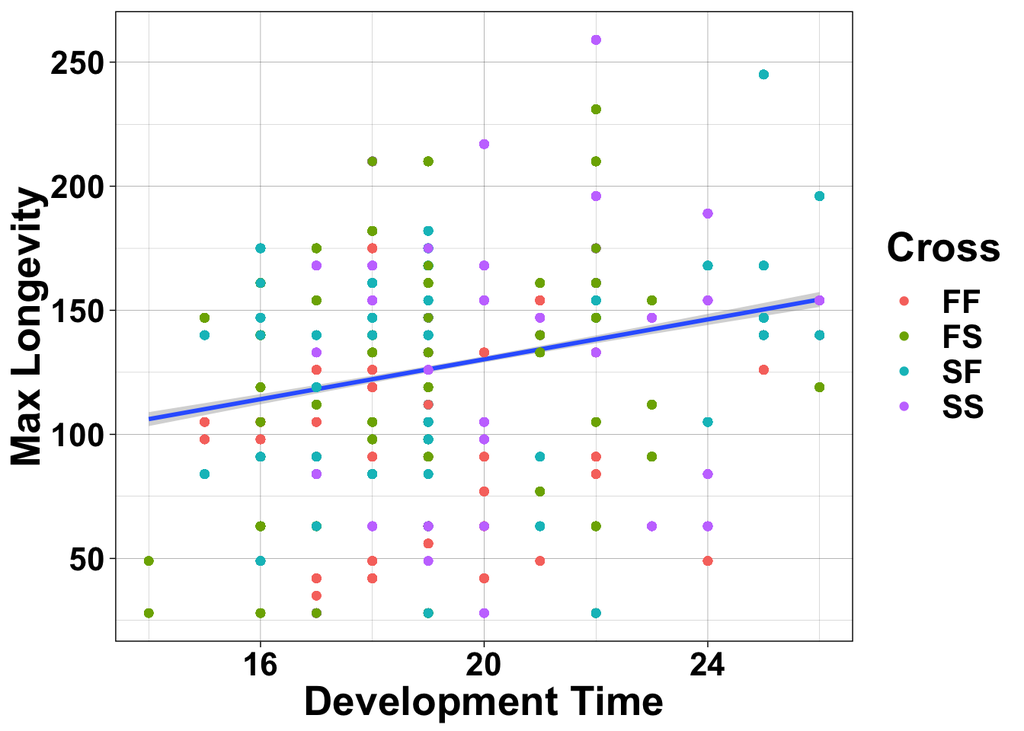

```r
datmast2$pops <- substr(datmast2$cross,1,2)

ggplot(na.omit(datmast2), aes(x = dev, y = max_longevity)) +
  geom_smooth(method = "lm") +
  geom_point(aes(color = pops)) +
  theme_linedraw() +
  xlab("Development Time") +
  ylab("Max Longevity") +
  theme(text=element_text(face="bold", size=20)) +
  guides(color=guide_legend(title=c("Cross")))
```

```r
fit <- lm(max_longevity~dev , na.omit(datmast2))
summary(fit)
```

```
##
## Call:
## lm(formula = max_longevity ~ dev, data = na.omit(datmast2))
##
## Residuals:
##      Min       1Q   Median       3Q      Max
## -110.285  -35.235    5.732   36.715  120.715
##
## Coefficients:
##             Estimate Std. Error t value Pr(>|t|)
## (Intercept)  49.9142     4.4752   11.15   <2e-16 ***
## dev           4.0169     0.2244   17.90   <2e-16 ***
## ---
## Signif. codes:  0 '***' 0.001 '**' 0.01 '*' 0.05 '.' 0.1 ' ' 1
##
## Residual standard error: 49.39 on 6102 degrees of freedom
## Multiple R-squared:  0.04989,    Adjusted R-squared:  0.04973
## F-statistic: 320.4 on 1 and 6102 DF,  p-value: < 2.2e-16
```

```r
cor.test(datmast2$max_longevity, datmast2$dev, method=c("pearson"))
```

```
##
##  Pearson's product-moment correlation
##
## data:  datmast2$max_longevity and datmast2$dev
## t = 17.9, df = 6102, p-value < 2.2e-16
## alternative hypothesis: true correlation is not equal to 0
## 95 percent confidence interval:
##  0.1993857 0.2470589
## sample estimates:
##       cor
## 0.2233559
```

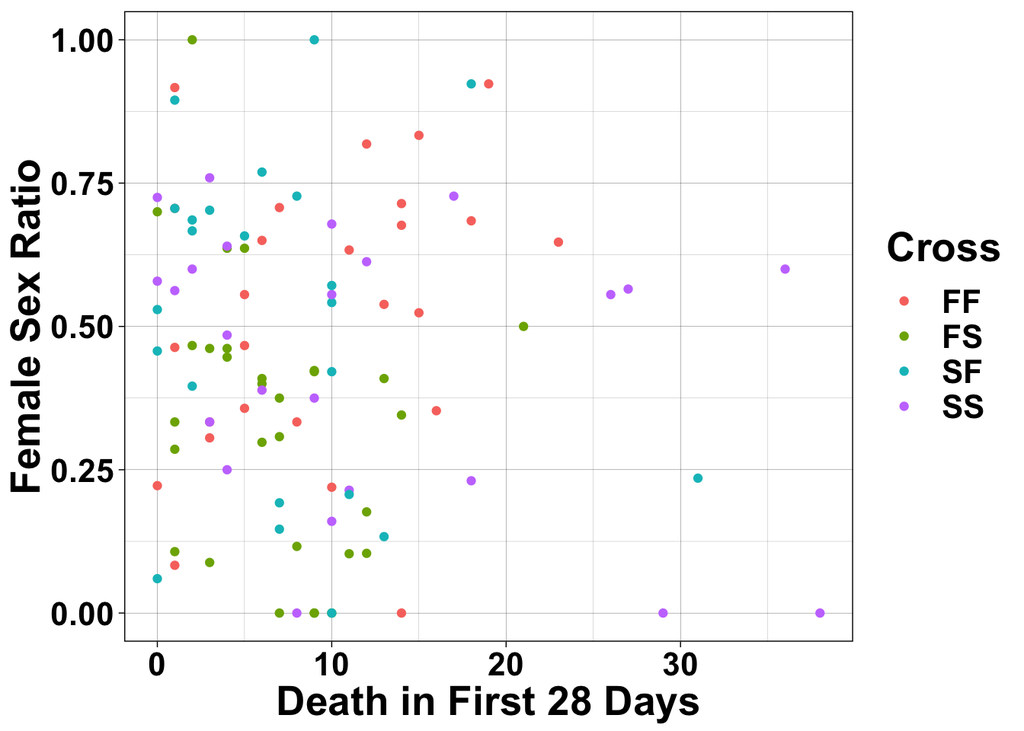

```
##
## Call:
## lm(formula = diff ~ prop_f, data = subset(tmp1, pops == "SS"))
##
## Residuals:
##     Min      1Q  Median      3Q     Max
## -10.801  -7.727  -4.339   4.483  26.316
##
## Coefficients:
##             Estimate Std. Error t value Pr(>|t|)
## (Intercept)   18.455      4.784   3.857 0.000854 ***
## prop_f       -14.618      9.561  -1.529 0.140511
## ---
## Signif. codes:  0 '***' 0.001 '**' 0.01 '*' 0.05 '.' 0.1 ' ' 1
##
## Residual standard error: 11.03 on 22 degrees of freedom
##   (1 observation deleted due to missingness)
## Multiple R-squared:  0.09606,    Adjusted R-squared:  0.05497
## F-statistic: 2.338 on 1 and 22 DF,  p-value: 0.1405
```

## Statistics CPH & K-M

```
##    Min. 1st Qu.  Median    Mean 3rd Qu.    Max.
##   35.00   49.00   56.00   59.58   63.00  175.00
```

```
## Call: survfit(formula = km2 ~ pops, data = tmp4)
##
##                 pops=FF
##   time n.risk n.event survival  std.err lower 95% CI upper 95% CI
##   31.5 424133   16854 9.60e-01 3.00e-04     9.60e-01     9.61e-01
##   38.5 407279   55502 8.29e-01 5.78e-04     8.28e-01     8.31e-01
##   45.5 351777  105174 5.81e-01 7.57e-04     5.80e-01     5.83e-01
##   52.5 246603   67748 4.22e-01 7.58e-04     4.20e-01     4.23e-01
##   59.5 178855   86919 2.17e-01 6.33e-04     2.16e-01     2.18e-01
##   73.5  91936   13934 1.84e-01 5.95e-04     1.83e-01     1.85e-01
##   80.5  78002   57508 4.83e-02 3.29e-04     4.77e-02     4.90e-02
##   87.5  20494   15640 1.14e-02 1.63e-04     1.11e-02     1.18e-02
##   94.5   4854     805 9.55e-03 1.49e-04     9.26e-03     9.84e-03
##  101.5   4049     754 7.77e-03 1.35e-04     7.51e-03     8.04e-03
##  108.5   3295     800 5.88e-03 1.17e-04     5.66e-03     6.12e-03
##  115.5   2495     156 5.51e-03 1.14e-04     5.30e-03     5.74e-03
##  122.5   2339     275 4.87e-03 1.07e-04     4.66e-03     5.08e-03
##  129.5   2064     590 3.48e-03 9.04e-05     3.30e-03     3.66e-03
##  136.5   1474     478 2.35e-03 7.43e-05     2.21e-03     2.50e-03
##  150.5    996     994 4.72e-06 3.33e-06     1.18e-06     1.89e-05
##  171.5      2       2 0.00e+00      NaN           NA           NA
##
##                 pops=FS
##   time n.risk n.event survival  std.err lower 95% CI upper 95% CI
##   31.5 732037   26744  0.96347 2.19e-04      0.96304      0.96390
##   38.5 705293   15642  0.94210 2.73e-04      0.94156      0.94263
##   45.5 689651   63102  0.85590 4.10e-04      0.85509      0.85670
##   52.5 626549   56006  0.77939 4.85e-04      0.77844      0.78034
##   59.5 570543   98616  0.64468 5.59e-04      0.64358      0.64577
##   73.5 471927   36974  0.59417 5.74e-04      0.59304      0.59529
##   80.5 434953   63450  0.50749 5.84e-04      0.50635      0.50864
##   87.5 371503   71960  0.40919 5.75e-04      0.40807      0.41032
##   94.5 299543   43130  0.35027 5.58e-04      0.34918      0.35137
##  101.5 256413   37877  0.29853 5.35e-04      0.29748      0.29958
##  108.5 218536   52324  0.22705 4.90e-04      0.22610      0.22802
##  115.5 166212   38086  0.17503 4.44e-04      0.17416      0.17590
##  122.5 128126   16154  0.15296 4.21e-04      0.15214      0.15379
##  129.5 111972   23282  0.12116 3.81e-04      0.12041      0.12190
##  136.5  88690   12578  0.10397 3.57e-04      0.10328      0.10467
##  143.5  76112   18774  0.07833 3.14e-04      0.07771      0.07894
```

[output cut: 52 more lines]

```
##  122.5  45066    5836 0.259082 1.13e-03     0.256885      0.26130
##  129.5  39230    8871 0.200497 1.03e-03     0.198490      0.20252
##  136.5  30359    9256 0.139368 8.90e-04     0.137635      0.14112
##  143.5  21103    3011 0.119483 8.34e-04     0.117860      0.12113
##  150.5  18092    5196 0.085168 7.17e-04     0.083773      0.08659
##  157.5  12896    4050 0.058421 6.03e-04     0.057251      0.05961
##  164.5   8846    2654 0.040893 5.09e-04     0.039908      0.04190
##  171.5   6192    1747 0.029356 4.34e-04     0.028518      0.03022
##  178.5   4445    1113 0.022005 3.77e-04     0.021279      0.02276
##  185.5   3332     910 0.015995 3.22e-04     0.015376      0.01664
##  192.5   2422     506 0.012654 2.87e-04     0.012103      0.01323
##  199.5   1916     816 0.007265 2.18e-04     0.006849      0.00771
##  206.5   1100     638 0.003051 1.42e-04     0.002786      0.00334
##  213.5    462     330 0.000872 7.58e-05     0.000735      0.00103
##  255.5    132     132 0.000000      NaN           NA           NA
```

```
## Call: survfit(formula = km2 ~ pops + sex, data = tmp4)
##
##                 pops=FF, sex=f
##   time n.risk n.event survival  std.err lower 95% CI upper 95% CI
##   31.5 261473   16308  0.93763 0.000473      0.93670      0.93856
##   38.5 245165   16716  0.87370 0.000650      0.87243      0.87497
##   45.5 228449   42554  0.71095 0.000887      0.70922      0.71269
##   52.5 185895   51538  0.51385 0.000977      0.51193      0.51577
##   59.5 134357   56269  0.29865 0.000895      0.29690      0.30041
##   73.5  78088   11588  0.25433 0.000852      0.25266      0.25600
##   80.5  66500   49250  0.06597 0.000485      0.06503      0.06693
##   87.5  17250   14534  0.01039 0.000198      0.01001      0.01078
##   94.5   2716     251  0.00943 0.000189      0.00906      0.00981
##  101.5   2465     214  0.00861 0.000181      0.00826      0.00897
##  108.5   2251     670  0.00605 0.000152      0.00576      0.00635
##  115.5   1581      72  0.00577 0.000148      0.00549      0.00607
##  122.5   1509     269  0.00474 0.000134      0.00449      0.00501
##  129.5   1240     260  0.00375 0.000120      0.00352      0.00399
##  136.5    980     196  0.00300 0.000107      0.00280      0.00322
##  150.5    784     784  0.00000      NaN           NA           NA
##
##                 pops=FF, sex=m
##   time n.risk n.event survival  std.err lower 95% CI upper 95% CI
##   31.5 162660     546 9.97e-01 1.43e-04     9.96e-01     9.97e-01
##   38.5 162114   38786 7.58e-01 1.06e-03     7.56e-01     7.60e-01
##   45.5 123328   62620 3.73e-01 1.20e-03     3.71e-01     3.76e-01
##   52.5  60708   16210 2.74e-01 1.11e-03     2.71e-01     2.76e-01
##   59.5  44498   30650 8.51e-02 6.92e-04     8.38e-02     8.65e-02
##   73.5  13848    2346 7.07e-02 6.36e-04     6.95e-02     7.20e-02
##   80.5  11502    8258 1.99e-02 3.47e-04     1.93e-02     2.06e-02
##   87.5   3244    1106 1.31e-02 2.82e-04     1.26e-02     1.37e-02
##   94.5   2138     554 9.74e-03 2.43e-04     9.27e-03     1.02e-02
##  101.5   1584     540 6.42e-03 1.98e-04     6.04e-03     6.82e-03
##  108.5   1044     130 5.62e-03 1.85e-04     5.27e-03     5.99e-03
##  115.5    914      84 5.10e-03 1.77e-04     4.77e-03     5.46e-03
##  122.5    830       6 5.07e-03 1.76e-04     4.73e-03     5.42e-03
##  129.5    824     330 3.04e-03 1.36e-04     2.78e-03     3.32e-03
##  136.5    494     282 1.30e-03 8.95e-05     1.14e-03     1.49e-03
##  150.5    212     210 1.23e-05 8.69e-06     3.08e-06     4.92e-05
##  171.5      2       2 0.00e+00      NaN           NA           NA
```

[output cut: 144 more lines]

```
##  122.5  29222    3170  0.31923 0.001632      0.31605      0.32245
##  129.5  26052    5962  0.24618 0.001508      0.24324      0.24915
##  136.5  20090    6488  0.16667 0.001305      0.16414      0.16925
##  143.5  13602    1404  0.14947 0.001248      0.14704      0.15194
##  150.5  12198    2734  0.11597 0.001121      0.11379      0.11819
##  157.5   9464    2900  0.08043 0.000952      0.07859      0.08232
##  164.5   6564    2170  0.05384 0.000790      0.05232      0.05541
##  171.5   4394     900  0.04281 0.000709      0.04145      0.04423
##  178.5   3494     404  0.03786 0.000668      0.03658      0.03920
##  185.5   3090     910  0.02671 0.000564      0.02563      0.02784
##  192.5   2180     264  0.02348 0.000530      0.02246      0.02454
##  199.5   1916     816  0.01348 0.000404      0.01271      0.01429
##  206.5   1100     638  0.00566 0.000263      0.00517      0.00620
##  213.5    462     330  0.00162 0.000141      0.00136      0.00192
##  255.5    132     132  0.00000      NaN           NA           NA
```

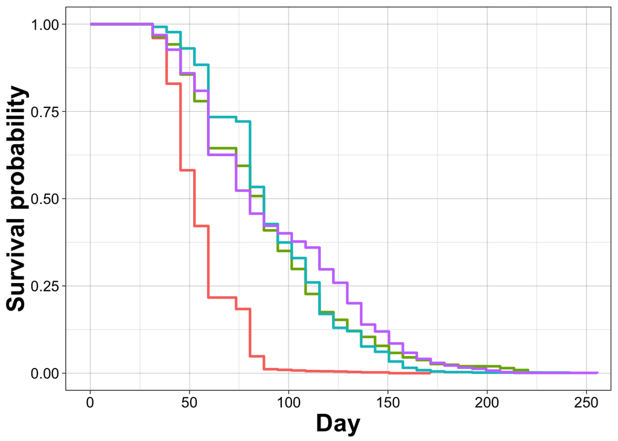

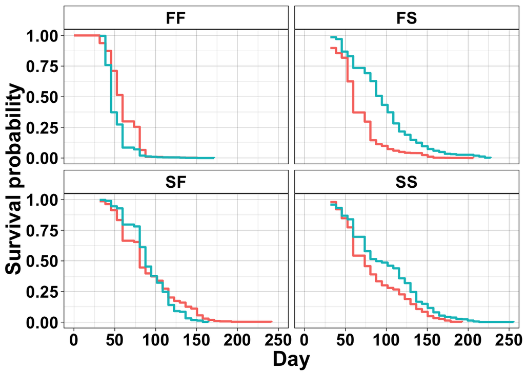

The surviorsip plots here using the km model and the porportion alive above likely don’t agree becasue the first shot took the mean from each family and the variation was due to family. :)